# Chi Squared Test

Skills Quiz

Andrew Seaman

2026-04-09

# Pages

## Home

### Introduction

The focus of this Skills Quiz is to learn how to setup, perform, and interpret a Chi-Squared based analysis.

### Questions

##### Q1

Introduction and textbook study.

##### Q2

Fill in the blank.

## Q1

##### 1.1

Mathematical model for a basic Chi-Squared test:
$$\chi^2 = \sum_{i=1}^m \frac{(O_i - E_i)^2}{E_i}$$

## Q2

Fill in the blank.

## Q3

##### 3.1

Run the following code in R. (This data is fabricated to mimic reality, but is not actual data.)

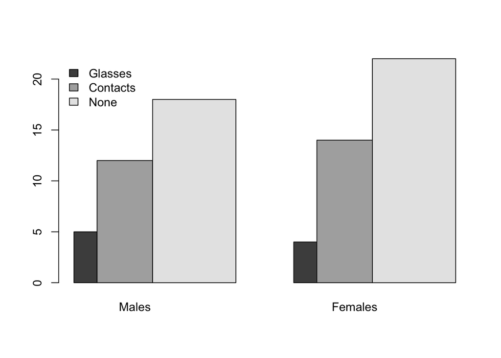

```r
# 3.1

# Table:

#create
glasses <- cbind( Males = c(Glasses = 5, Contacts = 12, None = 18), Females = c(Glasses = 4, Contacts = 14, None = 22))

#view
glasses %>%

#plot
barplot(glasses, beside=TRUE, legend.text=TRUE, args.legend=list(x = "topleft", bty="n"))
```

##### 3.2

Run the following code in R to determine if a chi-squared test of independence is appropriate for the glasses data.

```r
# 3.2

#chi-squared test
chis.glasses <- chisq.test(glasses)

#expected values
chis.glasses$expected %>% pander()
```

|  | Males | Females |
| --- | --- | --- |
| **Glasses** | 4.2 | 4.8 |
| **Contacts** | 12.13 | 13.87 |
| **None** | 18.67 | 21.33 |

##### 3.3

```r
# 3.3

mean(4.20000, 4.80000, 12.13333, 13.86667, 18.66667, 21.33333)
```

```
## [1] 4.2
```

##### 3.4

Run the following code in R to view the results of your test.

```r
# 3.4

chis.glasses %>% pander()
```

Pearson’s Chi-squared test: `glasses`

| Test statistic | df | P value |
| --- | --- | --- |
| 0.3331 | 2 | 0.8466 |

##### 3.5

Test residuals:

```r
# 3.5

chis.glasses$residuals  %>% pander()
```

|  | Males | Females |
| --- | --- | --- |
| **Glasses** | 0.3904 | -0.3651 |
| **Contacts** | -0.03828 | 0.03581 |
| **None** | -0.1543 | 0.1443 |

## Q4

##### 4.1

The following code gets this data into R.

```r
# 4.1

#build
education <- cbind( `United States` = c(Engineering = 61941, `Natural Science` = 111158, `Social Science` = 182166), `Western Europe` = c(Engineering = 158931, `Natural Science` = 140126, `Social Science` = 116353), Asia = c(280772, 242879, 236018))

#view
education %>% pander()
```

|  | United States | Western Europe | Asia |
| --- | --- | --- | --- |
| **Engineering** | 61941 | 158931 | 280772 |
| **Natural Science** | 111158 | 140126 | 242879 |
| **Social Science** | 182166 | 116353 | 236018 |

##### 4.2

```r
# 4.2

#chi-squared test
chis.education <- chisq.test(education)

#view
chis.education %>% pander()
```

Pearson’s Chi-squared test: `education`

| Test statistic | df | P value |
| --- | --- | --- |
| 69890 | 4 | 0 * * * |

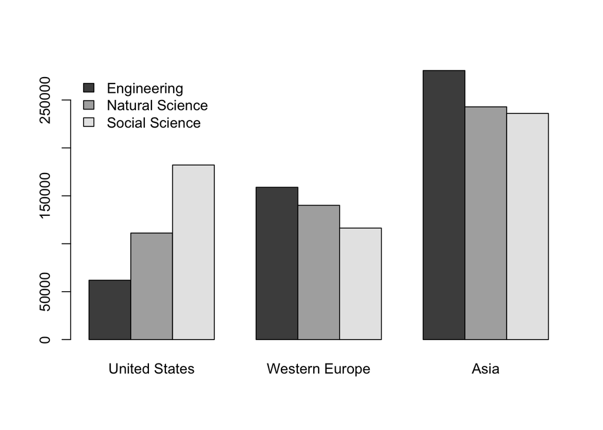

```r
#plot
barplot(education, beside=TRUE, legend.text=TRUE, args.legend=list(x = "topleft", bty="n"))
```

##### 4.3

Pearson test residuals

```r
# 4.3

#residuals
chis.education$residuals  %>% pander()
```

|  | United States | Western Europe | Asia |
| --- | --- | --- | --- |
| **Engineering** | -159.7 | 61.68 | 63.63 |
| **Natural Science** | -10.51 | 16.34 | -4.897 |
| **Social Science** | 164.9 | -75.47 | -56.94 |

## Q5

##### 5.1

Consider the InsectSprays dataset in R.

> ?InsectSprays

Test the hypothesis that the mean number of bugs killed by insectisides A, B, C, D, E, and F are all the same against the alternative that at least one mean is different.

```r
# 5.1

#contingency table
sprays <- table(InsectSprays$spray)
sprays %>% pander()
```

| A | B | C | D | E | F |
| --- | --- | --- | --- | --- | --- |
| 12 | 12 | 12 | 12 | 12 | 12 |

```r
#chi-squared test
chis.sprays <- chisq.test(sprays)
chis.sprays %>% pander()
```

Chi-squared test for given probabilities: `sprays`

| Test statistic | df | P value |
| --- | --- | --- |
| 0 | 5 | 1 |

```r
#expected values
chis.sprays$expected %>% pander()
```

| A | B | C | D | E | F |
| --- | --- | --- | --- | --- | --- |
| 12 | 12 | 12 | 12 | 12 | 12 |

##### 5.2

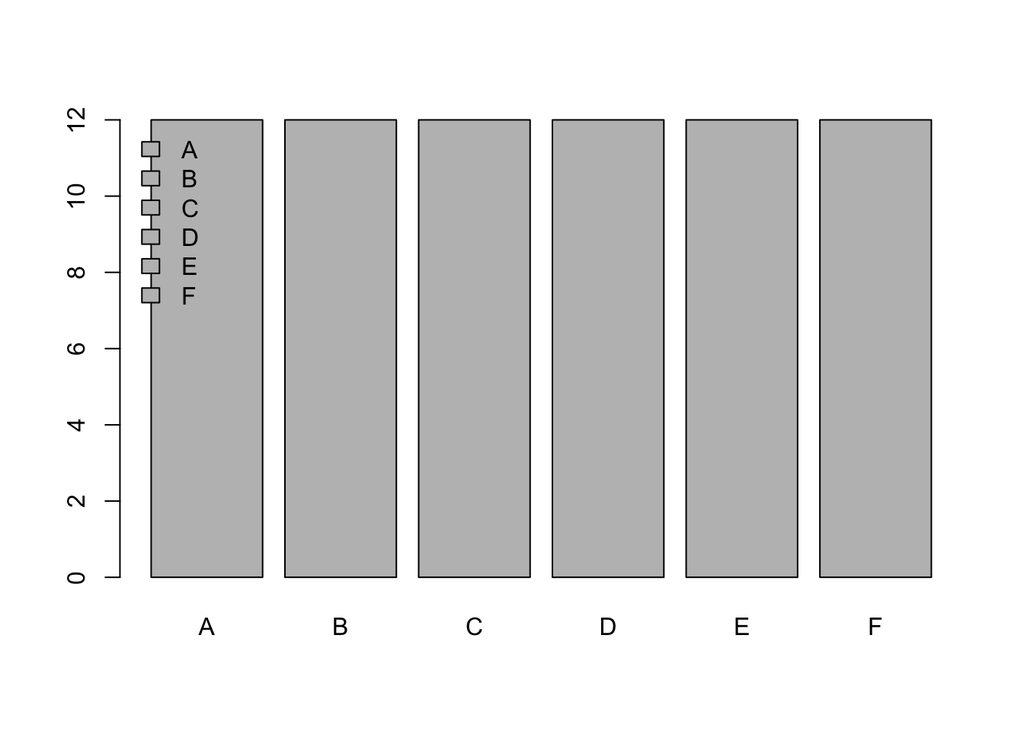

```r
# 5.2

#plot
barplot(sprays, beside=TRUE, legend.text=TRUE, args.legend=list(x = "topleft", bty="n"))
```

##### 5.3

Apparently I’m supposed to find the f-statistic for this test because ANOVA is a better fit for the data than chi-squared.

```r
# 5.3

#anova
anova_model <- aov(count ~ spray, data = InsectSprays)
summary(anova_model)
```

```
##             Df Sum Sq Mean Sq F value Pr(>F)
## spray        5   2669   533.8    34.7 <2e-16 ***
## Residuals   66   1015    15.4
## ---
## Signif. codes:  0 '***' 0.001 '**' 0.01 '*' 0.05 '.' 0.1 ' ' 1
```